# recount workshop: Learn to leverage 70,000 human RNA-seq samples for your projects

As shown in Figure 2, we can expand the biological metadata information by adding predictions based on RNA-seq data (14). The predictions include information about sex, sample source (cell line vs tissue), tissue and the sequencing strategy used. To add the predictions, simply use the function `add_predictions()` to expand the `colData()` slot.

```r
## Before adding predictions
dim(colData(rse_gene))
```

```
## [1]  8 24
```

```r
## Add the predictions
rse_gene <- add_predictions(rse_gene)
```

```
## 2017-07-21 13:04:16 downloading the predictions to /var/folders/cx/n9s558kx6fb7jf5z_pgszgb80000gn/T//Rtmpf8yvuV/PredictedPhenotypes_v0.0.03.rda
```

```r
## After adding the predictions
dim(colData(rse_gene))
```

```
## [1]  8 36
```

```r
## Explore the variables
colData(rse_gene)[, 25:ncol(colData(rse_gene))]
```

```
## DataFrame with 8 rows and 12 columns
##            reported_sex predicted_sex accuracy_sex reported_samplesource
##                <factor>      <factor>    <numeric>              <factor>
## SRR1931819           NA          male    0.8428571                tissue
## SRR1931818           NA          male    0.8428571                tissue
## SRR1931817           NA        female    0.8428571                tissue
## SRR1931816           NA        female    0.8428571                tissue
## SRR1931815           NA        female    0.8428571                tissue
## SRR1931814           NA        female    0.8428571                tissue
## SRR1931813           NA          male    0.8428571                tissue
## SRR1931812           NA        female    0.8428571                tissue
##            predicted_samplesource accuracy_samplesource reported_tissue
##                          <factor>             <numeric>        <factor>
## SRR1931819                 tissue             0.8923497              NA
## SRR1931818                 tissue             0.8923497              NA
## SRR1931817                 tissue             0.8923497              NA
## SRR1931816                 tissue             0.8923497              NA
## SRR1931815                 tissue             0.8923497              NA
## SRR1931814                 tissue             0.8923497              NA
## SRR1931813                 tissue             0.8923497              NA
## SRR1931812                 tissue             0.8923497              NA
##            predicted_tissue accuracy_tissue reported_sequencingstrategy
##                    <factor>       <numeric>                    <factor>
## SRR1931819            Brain       0.4707854                      SINGLE
## SRR1931818            Brain       0.4707854                      SINGLE
## SRR1931817            Brain       0.4707854                      SINGLE
## SRR1931816            Brain       0.4707854                      SINGLE
## SRR1931815            Brain       0.4707854                      SINGLE
## SRR1931814            Brain       0.4707854                      SINGLE
## SRR1931813            Brain       0.4707854                      SINGLE
## SRR1931812            Brain       0.4707854                      SINGLE
##            predicted_sequencingstrategy accuracy_sequencingstrategy
##                                <factor>                   <numeric>
## SRR1931819                       SINGLE                   0.8915381
## SRR1931818                       SINGLE                   0.8915381
## SRR1931817                       SINGLE                   0.8915381
## SRR1931816                       SINGLE                   0.8915381
## SRR1931815                       SINGLE                   0.8915381
## SRR1931814                       SINGLE                   0.8915381
## SRR1931813                       SINGLE                   0.8915381
## SRR1931812                       SINGLE                   0.8915381
```

From the predictions, we see that all samples are predicted to be from the brain, which matches the samples description. We also have predicted sex which we can compare against the reported sex.

```r
table("Observed" = colData(rse_gene)$sex,
    "Predicted" = colData(rse_gene)$predicted_sex)
```

```
##         Predicted
## Observed female male Unassigned
##   female      3    2          0
##   male        2    1          0
```

We have 4 sex prediction mismatches, which is very high. Let’s explore whether the sex is matching is related to other variables.

```r
## Is the sex matching? TRUE for yes.
colData(rse_gene)$matching_sex <- as.character(colData(rse_gene)$sex) ==
    as.character(colData(rse_gene)$predicted_sex)

## Matching sex vs other variables
table(colData(rse_gene)$matching_sex, colData(rse_gene)$case)
```

```
##
##         LOAD control
##   FALSE    2       2
##   TRUE     2       2
```

```r
table(colData(rse_gene)$matching_sex, colData(rse_gene)$age)
```

```
##
##         77 82 83 85 87 90
##   FALSE  0  0  2  1  1  0
##   TRUE   1  2  0  0  0  1
```

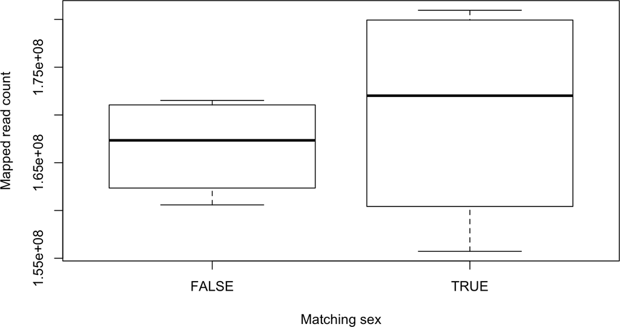

```r
boxplot(colData(rse_gene)$mapped_read_count ~ colData(rse_gene)$matching_sex,
    ylab = "Mapped read count", xlab = "Matching sex")
```

There are no discernible differences by case, age or mapped read count when compared with the matching sex status.

### 3.1.3 Adding more information

Ultimately, more sample metadata information could be available elsewhere which can be useful for analyses. This information might be provided in the paper describing the data, the SRA Run Selector or other sources. As shown in Figure 2, it is possible to append information to the `colData()` slot as long as there is a unique sample identifier such as the SRA Run id.

For our example use case, project SRP056604 has redundant information with the `characteristics` and the SRA Run selector https://trace.ncbi.nlm.nih.gov/Traces/study/?acc=SRP056604. However, this might not be the case for other projects. While the SRA Run Selector information is redundant in this case, we can practice adding it. We can download that information into text file named `SraRunTable.txt` by default, then load it into R, sort it appropriately and then append it to the `colData()` slot. Below we do so for the SRP056604 project.

```r
## Save the information from
## https://trace.ncbi.nlm.nih.gov/Traces/study/?acc=SRP056604
## to a table. We saved the file as SRP056604/SraRunTable.txt.
file.exists(file.path(local_path, "SraRunTable.txt"))
```

```
## [1] TRUE
```

```r
## Read the table
sra <- read.table(file.path(local_path, "SraRunTable.txt"),
    header = TRUE, sep = "\t")

## Explore it
head(sra)
```

```
##    BioSample_s Experiment_s MBases_l MBytes_l      Run_s SRA_Sample_s
## 1 SAMN03448725    SRX970047    17703    12139 SRR1931812    SRS885256
## 2 SAMN03448726    SRX970048    17024    11659 SRR1931813    SRS885255
## 3 SAMN03448730    SRX970049    16854    11560 SRR1931814    SRS885254
## 4 SAMN03448728    SRX970050    17806    12561 SRR1931815    SRS885253
## 5 SAMN03448727    SRX970051    16721    11576 SRR1931816    SRS885252
## 6 SAMN03448729    SRX970052    16418    11424 SRR1931817    SRS885251
##   Sample_Name_s apoe_genotype_s braak_stage_s gender_s
## 1    GSM1644996             3/3            VI   female
## 2    GSM1644997             3/3             V   female
## 3    GSM1644998             3/3            VI     male
## 4    GSM1644999             3/3            VI   female
## 5    GSM1645000             2/3             I   female
## 6    GSM1645001   Not available            II     male
##                    source_name_s                          subject_group_s
```

[output cut: 34 more lines]

```r
## We will remove some trailing '_s' from the variable names
colnames(sra) <- gsub("_s$", "", colnames(sra))

## Choose some variables we want to add
sra_vars <- c("braak_stage", "gender", "tissue")

## Re-organize the SRA table based on the SRA Run ids we have
sra <- sra[match(colData(rse_gene)$run, sra$Run), ]

## Double check the order
identical(colData(rse_gene)$run, as.character(sra$Run))
```

```
## [1] TRUE
```

```r
## Append the variables of interest
colData(rse_gene) <- cbind(colData(rse_gene), sra[, sra_vars])

## Final dimensions
dim(colData(rse_gene))
```

```
## [1]  8 40
```

```r
## Explore result
colData(rse_gene)[, 38:ncol(colData(rse_gene))]
```

```
## DataFrame with 8 rows and 3 columns
##            braak_stage   gender      tissue
##               <factor> <factor>    <factor>
## SRR1931819          II   female Hippocampus
## SRR1931818          II     male Hippocampus
## SRR1931817          II     male Hippocampus
## SRR1931816           I   female Hippocampus
## SRR1931815          VI   female Hippocampus
## SRR1931814          VI     male Hippocampus
## SRR1931813           V   female Hippocampus
## SRR1931812          VI   female Hippocampus
```

```r
## The sex information from the 'characteristics' and the
## SRA Run Selector match
table(colData(rse_gene)$gender, colData(rse_gene)$sex)
```

```
##
##          female male
##   female      5    0
##   male        0    3
```

## 3.2 DE setup

Now that we have all the metadata available we can perform a differential expression analysis. Lets look for differences by case when adjusting for the sex and age of the sample.

As we saw earlier in Figure 9, it is important to scale the coverage counts to read counts. To highlight the fact that we scaled the counts, we will use a new object name and delete the previous one. However, in practice we would simply overwrite the `rse` object with the output of `scale_counts(rse)`.

```r
## Scale counts
rse_gene_scaled <- scale_counts(rse_gene)

## To highlight that we scaled the counts
rm(rse_gene)
```

## 3.3 DE analysis

Now that we have scaled the counts, there are multiple differential expression packages we could use as described elsewhere (2,3). Since we have very few samples per group, we will use `DESeq2` (16). The model we will use will test for differential expression between LOAD and control samples, adjusting for sex and age. In a real use case we might have to explore the results with different models.

```r
library("DESeq2")

## Specify design and switch to DESeq2 format
dds <- DESeqDataSet(rse_gene_scaled, ~ sex + age + case)
```

```
## the design formula contains a numeric variable with integer values,
##   specifying a model with increasing fold change for higher values.
##   did you mean for this to be a factor? if so, first convert
##   this variable to a factor using the factor() function
```

```
## it appears that the last variable in the design formula, 'case',
##   has a factor level, 'control', which is not the reference level. we recommend
##   to use factor(...,levels=...) or relevel() to set this as the reference level
##   before proceeding. for more information, please see the 'Note on factor levels'
##   in vignette('DESeq2').
```

```r
## Perform DE analysis
dds <- DESeq(dds, test = "LRT", reduced = ~ sex + age, fitType = "local")
```

```
## 2 rows did not converge in beta, labelled in mcols(object)$fullBetaConv. Use larger maxit argument with nbinomLRT
```

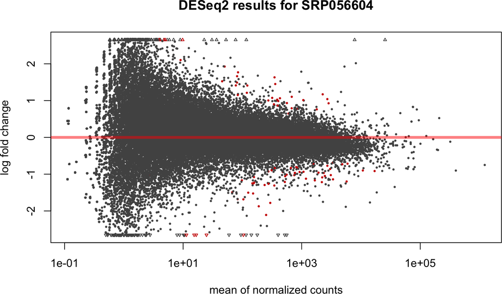

```r
res <- results(dds, alpha = 0.01)

## Explore results
plotMA(res, main="DESeq2 results for SRP056604")
```

We can use `ideal` (17) to make a volcano plot of the DE results.

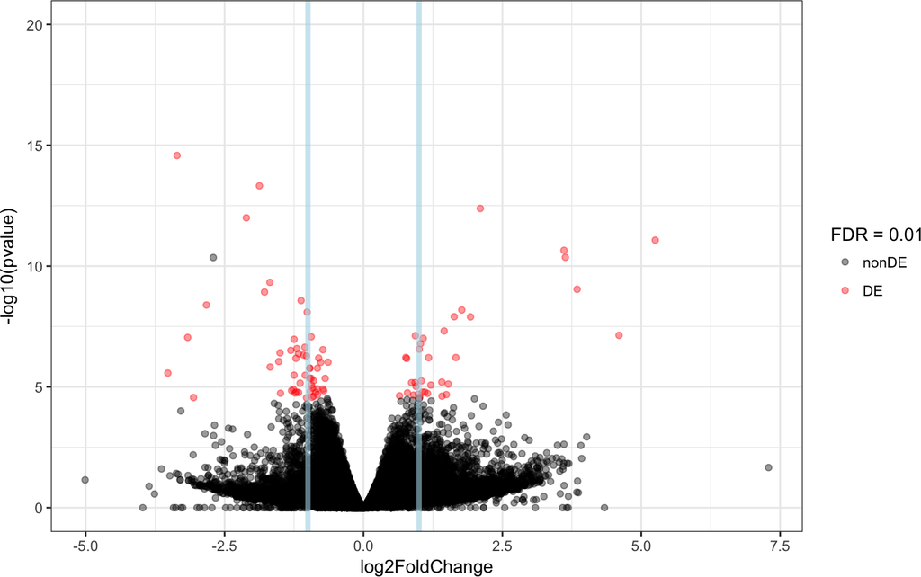

```r
## Make a volcano plot
library("ideal")
plot_volcano(res, FDR = 0.01)
```

## 3.4 DE report

Now that we have the differential expression results, we can use some of the tools with the biocView ReportWriting to create a report. One of them is `regionReport` (18) which can create reports from `DESeq2` (16) and `edgeR` (19) results. It can also handle `limma-voom` (20) results by making them look like `DESeq2` results.

We can now create the report, which should open automatically in a browser.

```r
## Make a report with the results
library("regionReport")
DESeq2Report(dds, res = res, project = "SRP056604",
    intgroup = c("sex", "case"), outdir = ".",
    output = "SRP056604_main-results")
```

If the report does not open automatically, we can open it with `browseURL()`.

```r
browseURL("SRP056604_main-results.html")
```

## 3.5 GO enrichment

Using `clusterProfiler` (21) we can then perform several enrichment analyses. The gene names from the recount2 objects use Gencode ids, which do not work by default with `org.Hs.eg.db`. To make sure they do, we can simply change the ids to Ensembl ids. Here we show how to perform an enrichment analysis using the biological process ontology. We will the genes that have a p-value as the universe background.

```r
library("clusterProfiler")
library("org.Hs.eg.db")

## Remember that dds had ENSEMBL ids for the genes
ensembl <- gsub("\\..*", "", rownames(dds))
head(ensembl)
```

```
## [1] "ENSG00000000003" "ENSG00000000005" "ENSG00000000419" "ENSG00000000457"
## [5] "ENSG00000000460" "ENSG00000000938"
```

```r
## Not all genes have a p-value
table(!is.na(res$padj))
```

```
##
## FALSE  TRUE
## 25863 32174
```

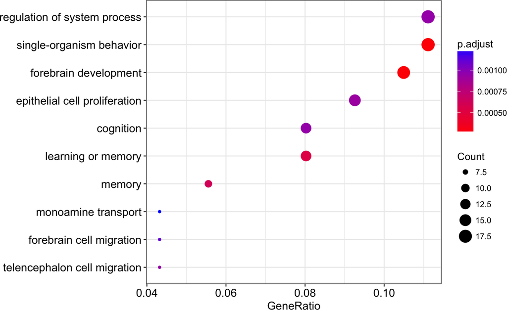

```r
## Perform enrichment analysis for Biological Process (BP)
## Note that the argument is keytype instead of keyType in Bioconductor 3.5
enrich_go <- enrichGO(gene = ensembl[which(res$padj < 0.05)],
    OrgDb = org.Hs.eg.db, keyType = "ENSEMBL", ont = "BP",
    pAdjustMethod = "BH", pvalueCutoff = 0.01, qvalueCutoff = 0.05,
    universe = ensembl[!is.na(res$padj)])

## Visualize enrichment results
dotplot(enrich_go)
```

Several other analyses can be performed with the resulting list of differentially expressed genes as described previously (2,3), although that is beyond the scope of this workshop.

## 3.6 Secondary analysis

Since we noticed that the sex predictions and the reported sex do not match for half of the samples, we can check if there are any genes associated with whether the sex matched.

```r
## DE analysis checking what genes are different by matching sex
dds2 <- DESeqDataSet(rse_gene_scaled, ~ matching_sex)
dds2 <- DESeq(dds2, test = "LRT", reduced = ~ 1, fitType = "local")
```

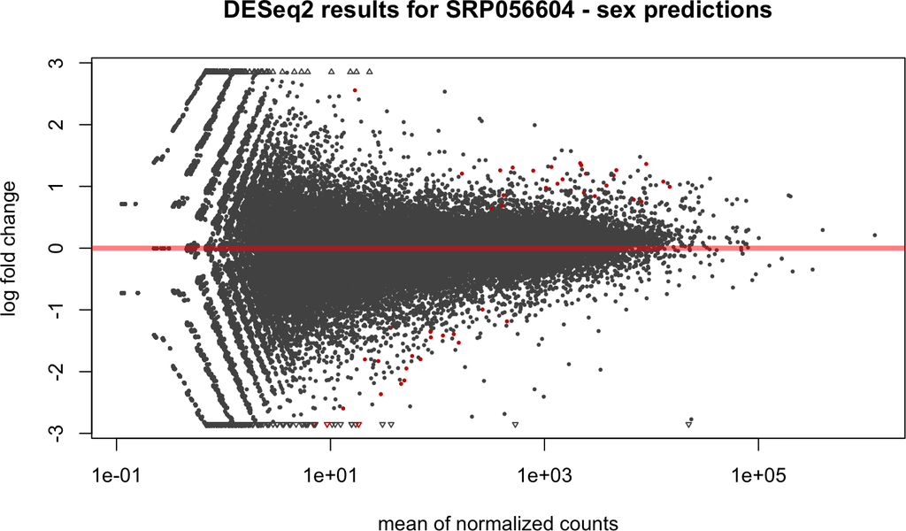

```r
res2 <- results(dds2, alpha = 0.01)

## Visually inspect results
plotMA(res2, main="DESeq2 results for SRP056604 - sex predictions")
```

```r
## Lets add gene symbols to the volcano plot, they are stored in
## the rowRanges slot of the rse object
rowRanges(rse_gene_scaled)
```

```
## GRanges object with 58037 ranges and 3 metadata columns:
##                      seqnames                 ranges strand |
##                         <Rle>              <IRanges>  <Rle> |
##   ENSG00000000003.14     chrX [100627109, 100639991]      - |
##    ENSG00000000005.5     chrX [100584802, 100599885]      + |
##   ENSG00000000419.12    chr20 [ 50934867,  50958555]      - |
##   ENSG00000000457.13     chr1 [169849631, 169894267]      - |
##   ENSG00000000460.16     chr1 [169662007, 169854080]      + |
##                  ...      ...                    ...    ... .
##    ENSG00000283695.1    chr19 [ 52865369,  52865429]      - |
##    ENSG00000283696.1     chr1 [161399409, 161422424]      + |
##    ENSG00000283697.1     chrX [149548210, 149549852]      - |
##    ENSG00000283698.1     chr2 [112439312, 112469687]      - |
##    ENSG00000283699.1    chr10 [ 12653138,  12653197]      - |
##                                 gene_id bp_length          symbol
##                             <character> <integer> <CharacterList>
##   ENSG00000000003.14 ENSG00000000003.14      4535          TSPAN6
##    ENSG00000000005.5  ENSG00000000005.5      1610            TNMD
##   ENSG00000000419.12 ENSG00000000419.12      1207            DPM1
##   ENSG00000000457.13 ENSG00000000457.13      6883           SCYL3
##   ENSG00000000460.16 ENSG00000000460.16      5967        C1orf112
##                  ...                ...       ...             ...
##    ENSG00000283695.1  ENSG00000283695.1        61              NA
##    ENSG00000283696.1  ENSG00000283696.1       997              NA
##    ENSG00000283697.1  ENSG00000283697.1      1184    LOC101928917
##    ENSG00000283698.1  ENSG00000283698.1       940              NA
##    ENSG00000283699.1  ENSG00000283699.1        60         MIR4481
##   -------
##   seqinfo: 25 sequences (1 circular) from an unspecified genome; no seqlengths
```

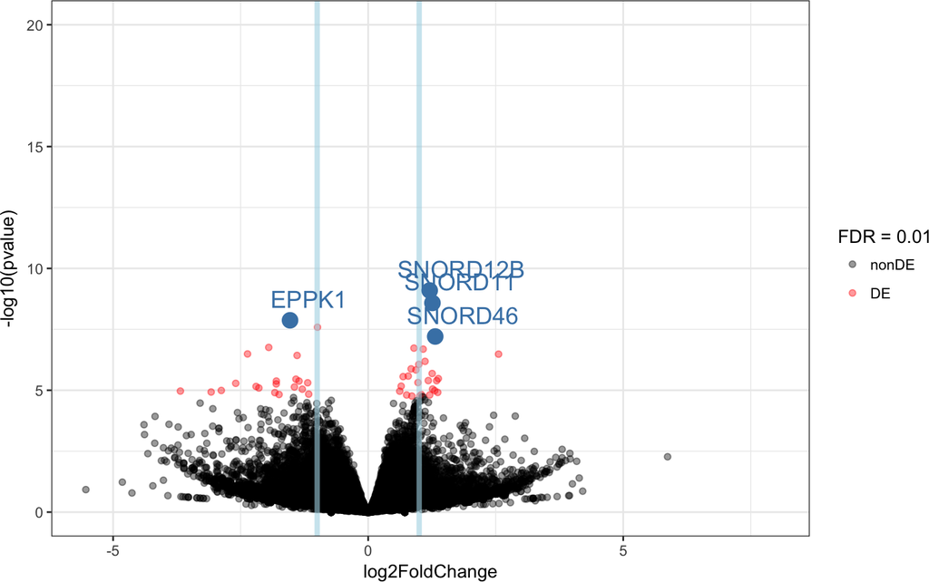

```r
res2$symbol <- sapply(rowRanges(rse_gene_scaled)$symbol, "[[", 1)

## Select some DE genes
intgenes <- res2$symbol[which(res2$padj < 0.0005)]
intgenes <- intgenes[!is.na(intgenes)]

## Make the volcano plot
plot_volcano(res2, FDR = 0.01, intgenes = intgenes)
```

We can create a report just like before.

```r
DESeq2Report(dds2, res = res2, project = "SRP056604 - matching sex",
    intgroup = c("sex", "predicted_sex"), outdir = ".",
    output = "SRP056604_sex-predictions")
```

Checking the chromosome of the DE genes by matching sex status shows that most of these genes are not in chromosomes X and Y as shown below.

```r
sort(table(seqnames(rowRanges(rse_gene_scaled))[which(res2$padj < 0.01)]))
```

```
##
## chr13 chr14 chr16 chr18 chr21  chrY  chrM  chr1  chr5  chr9 chr10  chr2
##     0     0     0     0     0     0     0     1     1     1     1     2
##  chr4  chr7 chr22  chrX  chr3  chr6 chr12 chr20  chr8 chr15 chr19 chr11
##     2     2     2     2     3     3     3     3     4     4     4     5
## chr17
##     5
```

# 4 Other features

As described in Figure 1, recount2 provides data for expression features beyond genes. In this section we perform a differential expression analysis using the exon data as well as the base-pair resolution information.

## 4.1 Exon and exon-exon junctions

The exon and exon-exon junction coverage count matrices are similar to the gene level one and can also be downloaded with `download_study()`. However, these coverage count matrices are much larger than the gene one. Aggressive filtering of lowly expressed exons or exon-exon junctions can reduce the matrix dimensions if this impacts the performance of the differential expression software used.

```r
## Download the data if it is not there
if(!file.exists(file.path(local_path, "rse_exon.Rdata"))) {
    ## In case you decide to download the data instead of using the
    ## pre-installed data
    local_path <- "SRP056604"
    download_study("SRP056604", type = "rse-exon")
}

## Load the data
load(file.path(local_path, "rse_exon.Rdata"))

## Scale and add the metadata (it is in the same order)
identical(colData(rse_exon)$run, colData(rse_gene_scaled)$run)
```

```
## [1] TRUE
```

```r
colData(rse_exon) <- colData(rse_gene_scaled)
rse_exon_scaled <- scale_counts(rse_exon)
## To highlight that we scaled the counts
rm(rse_exon)

## Filter lowly expressed exons: reduces the object size
## and run time
filter_exon <- rowMeans(assays(rse_exon_scaled)$counts) > 5
round(table(filter_exon) / length(filter_exon) * 100, 2)
```

```
## filter_exon
## FALSE  TRUE
## 51.59 48.41
```

```r
## Perform the filtering and change default names
rse_e <- rse_exon_scaled[filter_exon, ]
rowRanges(rse_e)$gene_id <- rownames(rse_e)
rownames(rse_e) <- paste0("exon_", seq_len(nrow(rse_e)))

## Create DESeq2 object for the exon data
dds_exon <- DESeqDataSet(rse_e, ~ sex + age + case)
```

```
## the design formula contains a numeric variable with integer values,
##   specifying a model with increasing fold change for higher values.
##   did you mean for this to be a factor? if so, first convert
##   this variable to a factor using the factor() function
```

```
## it appears that the last variable in the design formula, 'case',
##   has a factor level, 'control', which is not the reference level. we recommend
##   to use factor(...,levels=...) or relevel() to set this as the reference level
##   before proceeding. for more information, please see the 'Note on factor levels'
##   in vignette('DESeq2').
```

```r
## Perform DE analysis
dds_exon <- DESeq(dds_exon, test = "LRT", reduced = ~ sex + age,
    fitType = "local")
```

```
## 1 rows did not converge in beta, labelled in mcols(object)$fullBetaConv. Use larger maxit argument with nbinomLRT
```

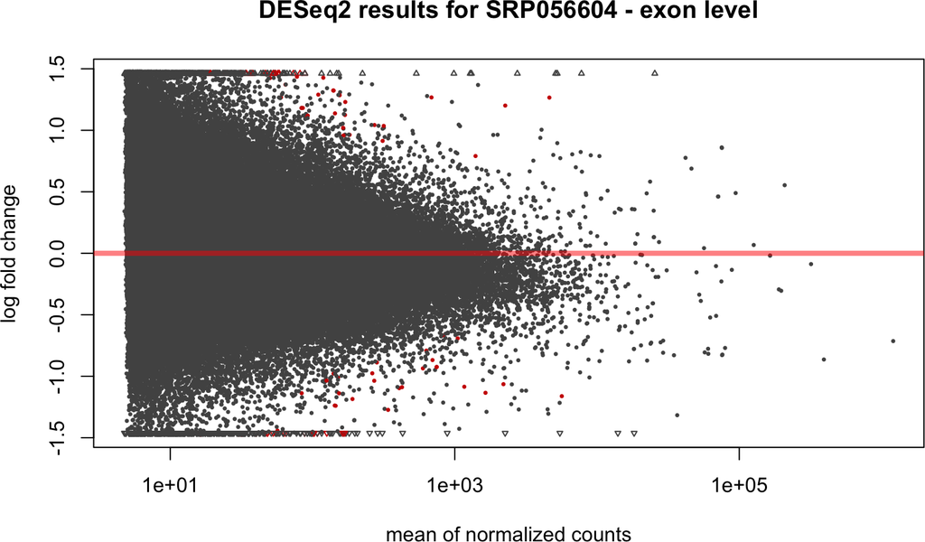

```r
res_exon <- results(dds_exon, alpha = 0.01)

## Explore results
plotMA(res_exon, main="DESeq2 results for SRP056604 - exon level")
```

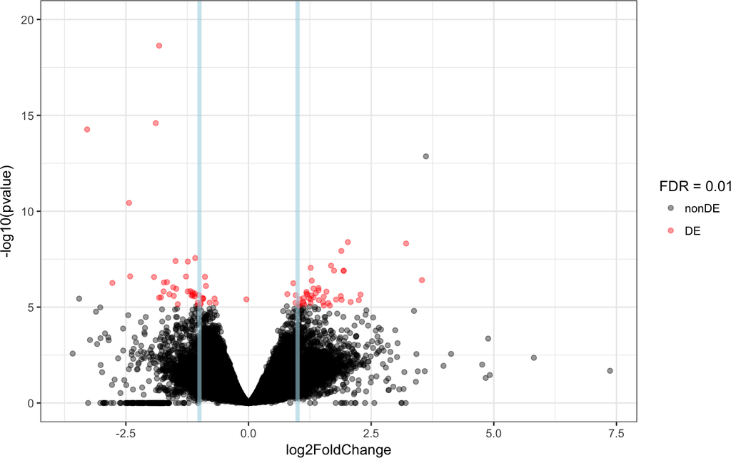

```r
plot_volcano(res_exon, FDR = 0.01)
```

Just like at the gene level, we see many exons differentially expressed between LOAD and controls samples. As a first step to integrate the results from the two features, we can compare the list of genes that are differentially expressed versus the genes that have at least one exon differentially expressed.

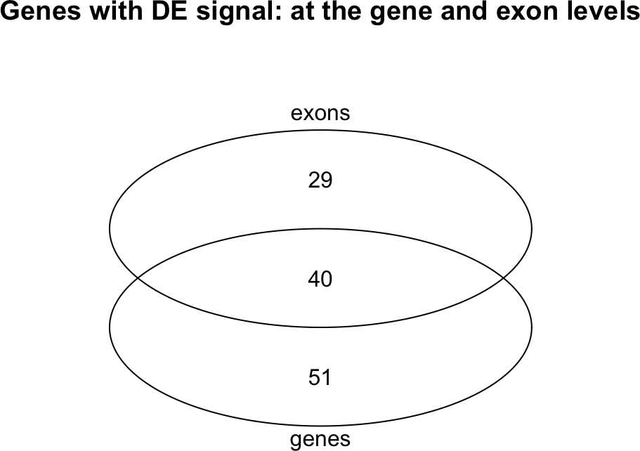

```
## integer(0)
```

```r
## Get the gene ids for genes that are DE at the gene level or that have at
## least one exon with DE signal.
genes_w_de_exon <- unique(rowRanges(rse_e)$gene_id[which(res_exon$padj < 0.01)])
genes_de <- rownames(rse_gene_scaled)[which(res$padj < 0.01)]

## Make a venn diagram
library("gplots")
vinfo <- venn(list("genes" = genes_de, "exons" = genes_w_de_exon),
    names = c("genes", "exons"), show.plot = FALSE)
plot(vinfo) +
    title("Genes with DE signal: at the gene and exon levels")
```

Not all differentially expressed genes have differentially expressed exons, nor genes with at least one differentially expressed exon are necessarily differentially expressed. This is in line with what was described in Figure 2B of Soneson et al., 2015 (22).

This was just a quick example of how we can perform differential expression analyses at the gene and exon feature levels. We envision that more involved pipelines could be developed that leverage both feature levels such as in Jaffe at al., 2017 (23). For instance, we could focus on the differentially expressed genes with at least one differentially expressed exon and compare the direction of the DE signal versus the gene level signal as shown below.

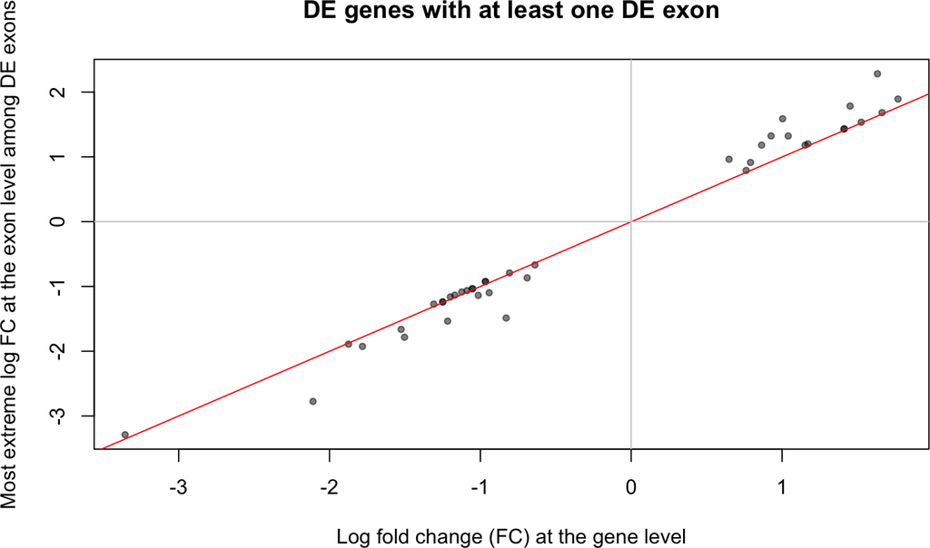

```r
## Keep only the DE exons that are from a gene that is also DE
top_exon_de <- res_exon[intersect(which(res_exon$padj < 0.01),
    which(rowRanges(rse_e)$gene_id %in%
    attr(vinfo, "intersections")[["genes:exons"]])), ]
## Add the gene id
top_exon_de$gene_id <- rowRanges(rse_e)$gene_id[match(rownames(top_exon_de),
    rownames(rse_e))]

## Find the fold change that is the most extreme among the DE exons of a gene
exon_max_fc <- tapply(top_exon_de$log2FoldChange, top_exon_de$gene_id,
    function(x) { x[which.max(abs(x))] })

## Keep only the DE genes that match the previous selection
top_gene_de <- res[match(names(exon_max_fc), rownames(res)), ]

## Make the plot
plot(top_gene_de$log2FoldChange, exon_max_fc, pch = 20,
    col = adjustcolor("black", 1/2),
    ylab = "Most extreme log FC at the exon level among DE exons",
    xlab = "Log fold change (FC) at the gene level",
    main = "DE genes with at least one DE exon")
abline(a = 0, b = 1, col = "red")
abline(h = 0, col = "grey80")
abline(v = 0, col = "grey80")
```

The fold change for most exons shown above agrees with the gene level fold change. In data from other projects, some of the fold changes have opposite directions and could be interesting to study further.

## 4.2 Base-pair resolution

recount2 provides BigWig coverage files (unscaled) for all samples as well as a mean BigWig coverage file per project where each sample was scaled to 40 million 100 base-pair reads. The mean BigWig files are exactly what is needed to start an *expressed regions* analysis with `derfinder` (8). `recount` provides two related functions: `expressed_regions()` which is used to define a set of regions based on the mean BigWig file for a given project, and `coverage_matrix()` which based on a set of regions builds a count coverage matrix in a *RangedSummarizedExperiment* object just like the ones that are provided for genes and exons. Both functions ultimately use `import.bw()` from `rtracklayer` (24) which currently is not supported on Windows machines. While this presents a portability disadvantage, on the other side it allows reading portions of BigWig files from the web without having to fully download them. `download_study()` with `type = "mean"` or `type = "samples"` can be used to download the BigWig files, which we recommend doing when working with them extensively.

For illustrative purposes, we will use the data from chromosome 12 for the SRP056604 project. We chose chromosome 12 based on the number of DE genes per chromosome

```r
sort(table(seqnames(rowRanges(rse_gene_scaled)[which(res$padj < 0.01)])),
    decreasing = TRUE)
```

```
##
## chr12 chr15  chr6 chr14  chr4  chr5  chr7  chr8 chr13  chr1  chr2 chr11
##     9     8     6     6     5     5     5     5     5     4     4     4
## chr17  chrX  chr3 chr10  chr9 chr18 chr20 chr22 chr16 chr21  chrY chr19
##     4     4     3     3     2     2     2     2     1     1     1     0
##  chrM
##     0
```

```r
## Define expressed regions for study SRP056604, only for chromosome 12
regions <- expressed_regions("SRP056604", "chr12", cutoff = 5L,
    maxClusterGap = 3000L, outdir = local_path)
```

```
## 2017-07-21 13:08:50 loadCoverage: loading BigWig file /private/var/folders/cx/n9s558kx6fb7jf5z_pgszgb80000gn/T/RtmpwJ8P4y/Rinst93b46ccf6c6a/recountWorkshop/extdata/SRP056604/bw/mean_SRP056604.bw
```

```
## 2017-07-21 13:09:10 loadCoverage: applying the cutoff to the merged data
```

```
## 2017-07-21 13:09:10 filterData: originally there were 133275309 rows, now there are 133275309 rows. Meaning that 0 percent was filtered.
```

```
## 2017-07-21 13:09:10 findRegions: identifying potential segments
```

```
## 2017-07-21 13:09:10 findRegions: segmenting information
```

```
## 2017-07-21 13:09:10 .getSegmentsRle: segmenting with cutoff(s) 5
```

```
## 2017-07-21 13:09:16 findRegions: identifying candidate regions
```

```
## 2017-07-21 13:09:18 findRegions: identifying region clusters
```

```r
## Explore the resulting expressed regions
regions
```

```
## GRanges object with 45415 ranges and 6 metadata columns:
##         seqnames                 ranges strand |            value
##            <Rle>              <IRanges>  <Rle> |        <numeric>
##       1    chr12         [14557, 14609]      * | 5.51228961404764
##       2    chr12         [14694, 14944]      * | 18.5175433177872
##       3    chr12         [15085, 15153]      * | 32.1930030463398
##       4    chr12         [15489, 15589]      * | 15.5183322169993
##       5    chr12         [15889, 16065]      * | 51.5721219623156
##     ...      ...                    ...    ... .              ...
##   45411    chr12 [133204363, 133204806]      * | 14.7140764245042
##   45412    chr12 [133205808, 133205818]      * | 5.28275680541992
##   45413    chr12 [133206109, 133206245]      * | 9.16745478219359
##   45414    chr12 [133206247, 133206273]      * | 5.30814688294022
##   45415    chr12 [133206625, 133206646]      * | 5.22780539772727
##                     area indexStart  indexEnd cluster clusterL
##                <numeric>  <integer> <integer>   <Rle>    <Rle>
##       1 292.151349544525      14557     14609       1    16374
##       2 4647.90337276459      14694     14944       1    16374
##       3 2221.31721019745      15085     15153       1    16374
##       4 1567.35155391693      15489     15589       1    16374
##       5 9128.26558732986      15889     16065       1    16374
##     ...              ...        ...       ...     ...      ...
##   45411 6533.04993247986  133204363 133204806    4711     4503
##   45412 58.1103248596191  133205808 133205818    4711     4503
##   45413 1255.94130516052  133206109 133206245    4711     4503
##   45414 143.319965839386  133206247 133206273    4711     4503
##   45415     115.01171875  133206625 133206646    4711     4503
##   -------
##   seqinfo: 1 sequence from an unspecified genome
```

```r
summary(width(regions))
```

```
##    Min. 1st Qu.  Median    Mean 3rd Qu.    Max.
##     1.0     9.0    61.0    88.3   120.0  5483.0
```

```r
table(width(regions) >= 60)
```

```
##
## FALSE  TRUE
## 22465 22950
```

```r
## Keep only the ones that are at least 60 bp long
regions <- regions[width(regions) >= 60]
length(regions)
```

```
## [1] 22950
```

Now that we have a set of regions to work with, we proceed to build a *RangedSummarizedExperiment* object with the coverage counts, add the expanded metadata we built for the gene level, and scale the counts.

```r
## Compute coverage matrix for study SRP056604, only for chromosome 12
## Takes about 45 seconds with local data
## and about 70 seconds with data from the web
system.time(rse_er <- coverage_matrix("SRP056604", "chr12", regions,
    chunksize = length(regions), outdir = local_path))
```

```
## 2017-07-21 13:09:27 railMatrix: processing regions 1 to 22950
```

```
## 2017-07-21 13:09:27 railMatrix: processing file /private/var/folders/cx/n9s558kx6fb7jf5z_pgszgb80000gn/T/RtmpwJ8P4y/Rinst93b46ccf6c6a/recountWorkshop/extdata/SRP056604/bw/SRR1931819.bw
```

```
## 2017-07-21 13:09:37 railMatrix: processing file /private/var/folders/cx/n9s558kx6fb7jf5z_pgszgb80000gn/T/RtmpwJ8P4y/Rinst93b46ccf6c6a/recountWorkshop/extdata/SRP056604/bw/SRR1931818.bw
```

```
## 2017-07-21 13:09:44 railMatrix: processing file /private/var/folders/cx/n9s558kx6fb7jf5z_pgszgb80000gn/T/RtmpwJ8P4y/Rinst93b46ccf6c6a/recountWorkshop/extdata/SRP056604/bw/SRR1931817.bw
```

```
## 2017-07-21 13:09:50 railMatrix: processing file /private/var/folders/cx/n9s558kx6fb7jf5z_pgszgb80000gn/T/RtmpwJ8P4y/Rinst93b46ccf6c6a/recountWorkshop/extdata/SRP056604/bw/SRR1931816.bw
```

```
## 2017-07-21 13:09:56 railMatrix: processing file /private/var/folders/cx/n9s558kx6fb7jf5z_pgszgb80000gn/T/RtmpwJ8P4y/Rinst93b46ccf6c6a/recountWorkshop/extdata/SRP056604/bw/SRR1931815.bw
```

```
## 2017-07-21 13:10:03 railMatrix: processing file /private/var/folders/cx/n9s558kx6fb7jf5z_pgszgb80000gn/T/RtmpwJ8P4y/Rinst93b46ccf6c6a/recountWorkshop/extdata/SRP056604/bw/SRR1931814.bw
```

```
## 2017-07-21 13:10:11 railMatrix: processing file /private/var/folders/cx/n9s558kx6fb7jf5z_pgszgb80000gn/T/RtmpwJ8P4y/Rinst93b46ccf6c6a/recountWorkshop/extdata/SRP056604/bw/SRR1931813.bw
```

```
## 2017-07-21 13:10:18 railMatrix: processing file /private/var/folders/cx/n9s558kx6fb7jf5z_pgszgb80000gn/T/RtmpwJ8P4y/Rinst93b46ccf6c6a/recountWorkshop/extdata/SRP056604/bw/SRR1931812.bw
```

```
##    user  system elapsed
##  40.290   8.076  58.060
```

```r
## Use the expanded metadata we built for the gene model
colData(rse_er) <- colData(rse_gene_scaled)

## Normally, we would scale the counts but that leads
## to very small numbers in this example.
colSums(assays(scale_counts(rse_er))$counts)
```

```
## SRR1931819 SRR1931818 SRR1931817 SRR1931816 SRR1931815 SRR1931814 SRR1931813
##       2066       2192       1529       1783       1416       1693       1651
## SRR1931812
##       1778
```

```r
summary(rowMeans(assays(scale_counts(rse_er))$counts))
```

```
##     Min.  1st Qu.   Median     Mean  3rd Qu.     Max.
##  0.00000  0.00000  0.00000  0.07684  0.00000 58.62500
```

```r
## So instead of scaling, we will transform to integers
## keeping numbers around the 1 million counts
colSums(assays(rse_er)$counts)
```

```
## SRR1931819 SRR1931818 SRR1931817 SRR1931816 SRR1931815 SRR1931814 SRR1931813
##  1197857.5  1217328.7   892244.8  1051703.6  1139072.1  1168633.2  1134101.9
## SRR1931812
##  1174644.7
```

```r
assays(rse_er)$counts <- round(assays(rse_er)$counts, 0)
colSums(assays(rse_er)$counts)
```

```
## SRR1931819 SRR1931818 SRR1931817 SRR1931816 SRR1931815 SRR1931814 SRR1931813
##    1197866    1217314     892266    1051706    1139119    1168614    1134118
## SRR1931812
##    1174655
```

Now that we have an integer count matrix for the expressed regions, we can proceed with the differential expression analysis just like we did at the gene and exon feature levels.

```r
## Define DESeq2 object
dds_er <- DESeqDataSet(rse_er, ~ sex + age + case)
```

```
## the design formula contains a numeric variable with integer values,
##   specifying a model with increasing fold change for higher values.
##   did you mean for this to be a factor? if so, first convert
##   this variable to a factor using the factor() function
```

```
## it appears that the last variable in the design formula, 'case',
##   has a factor level, 'control', which is not the reference level. we recommend
##   to use factor(...,levels=...) or relevel() to set this as the reference level
##   before proceeding. for more information, please see the 'Note on factor levels'
##   in vignette('DESeq2').
```

```r
dds_er <- DESeq(dds_er, test = "LRT", reduced = ~ sex + age, fitType = "local")
```

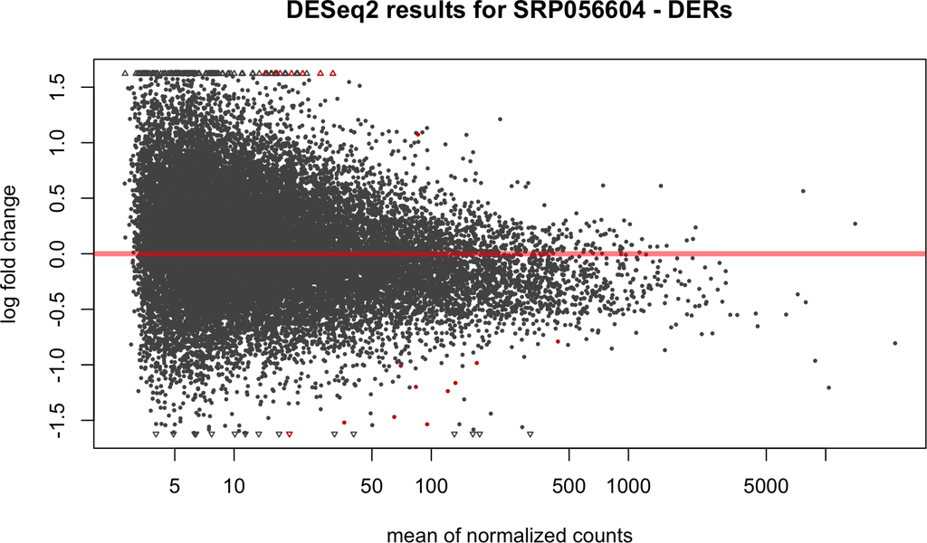

```r
res_er <- results(dds_er, alpha = 0.05)

## Visually inspect results
plotMA(res_er, main="DESeq2 results for SRP056604 - DERs")
```

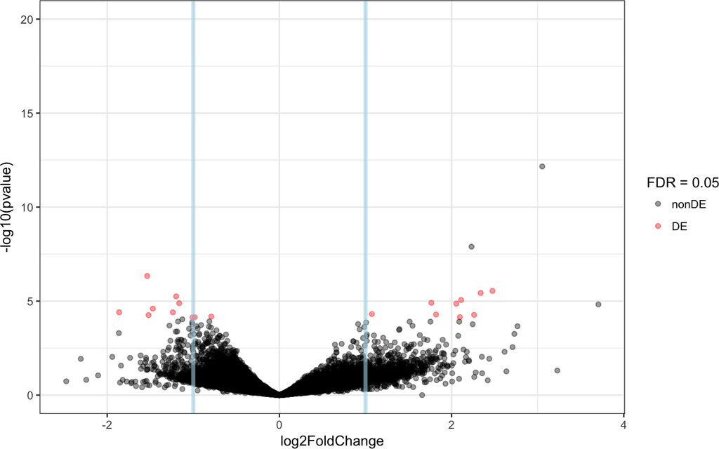

```r
plot_volcano(res_er, FDR = 0.05)
```

We can also create a report, just like before.

```r
DESeq2Report(dds_er, res = res_er, project = "SRP056604 - DERs",
    intgroup = c("sex", "case"), outdir = ".",
    output = "SRP056604_DERs")
```

Having identified the differentially expressed regions (DERs), we can sort all regions by their adjusted p-value.

```r
## Sort regions by q-value
regions_by_padj <- regions[order(res_er$padj, decreasing = FALSE)]

## Look at the top 10
regions_by_padj[1:10]
```

```
## GRanges object with 10 ranges and 6 metadata columns:
##         seqnames                 ranges strand |            value
##            <Rle>              <IRanges>  <Rle> |        <numeric>
##   34249    chr12 [108250663, 108250900]      * |  38.194384272359
##    1567    chr12 [  2189828,   2189963]      * | 11.6252035463558
##   18192    chr12 [ 54963840,  54963950]      * | 17.1647116472055
##   29356    chr12 [ 91178342,  91178585]      * | 34.8185044624766
##   10648    chr12 [ 29767898,  29768075]      * | 74.1435057607929
##   18188    chr12 [ 54962431,  54962638]      * | 11.6006789757655
##   18191    chr12 [ 54962854,  54963101]      * | 13.8672616866327
##   18200    chr12 [ 54967146,  54967243]      * | 21.5609737415703
##   34250    chr12 [108250902, 108251194]      * | 21.5030734612266
##   34258    chr12 [108253988, 108254830]      * | 13.9660946477209
##                     area indexStart  indexEnd cluster clusterL
##                <numeric>  <integer> <integer>   <Rle>    <Rle>
##   34249 9090.26345682144  108250663 108250900    3633    20890
##    1567 1581.02768230438    2189828   2189963     147   140108
##   18192 1905.28299283981   54963840  54963950    1940     9191
##   29356  8495.7150888443   91178342  91178585    3007     1163
##   10648 13197.5440254211   29767898  29768075    1187      178
##   18188 2412.94122695923   54962431  54962638    1940     9191
##   18191 3439.08089828491   54962854  54963101    1940     9191
##   18200 2112.97542667389   54967146  54967243    1940     9191
##   34250  6300.4005241394  108250902 108251194    3633    20890
##   34258 11773.4177880287  108253988 108254830    3633    20890
##   -------
##   seqinfo: 1 sequence from an unspecified genome
```

```r
width(regions_by_padj[1:10])
```

```
##  [1] 238 136 111 244 178 208 248  98 293 843
```

## 4.3 Visualize regions

Since the DERs do not necessarily match the annotation, it is important to visualize them. The code for visualizing DERs can easily be adapted to visualize other regions. Although, the width and number of the regions will influence the computing resources needed to make the plots.

Because the unscaled BigWig files are available in recount2, several visualization packages can be used such as `epivizr` (25), `wiggleplotr` (26) and `derfinderPlot` (8). With all of them it is important to remember to scale the data except when visualizing the mean BigWig file for a given project.

First, we need to get the list of URLs for the BigWig files. We can either manually construct them or search them inside the `recount_url` table. For this workshop, we have the data locally so we will use those files.

```r
## Construct the list of BigWig URLs
## They have the following form:
## http://duffel.rail.bio/recount/
## project id
## /bw/
## sample run id
## .bw
bws_web <- paste0("http://duffel.rail.bio/recount/SRP056604/bw/",
    colData(rse_er)$bigwig_file)

## Note that they are also present in the recount_url data.frame
bws_url <- recount_url$url[match(colData(rse_er)$bigwig_file,
    recount_url$file_name)]
identical(bws_web, bws_url)
```

```
## [1] TRUE
```

```r
## Local bigwigs
bws <- file.path(local_path, "bw", colData(rse_er)$bigwig_file)
all(file.exists(bws))
```

```
## [1] TRUE
```

```r
## Use the sample run ids as the sample names
names(bws) <- colData(rse_er)$run
```

We will visualize the DERs using `derfinderPlot`, similar to what was done in Jaffe et al., 2015 (27). We will first add a little padding to the regions: 100 base-pairs on each side.

```r
## Add 100 bp padding on each side
regions_resized <- resize(regions_by_padj[1:10],
    width(regions_by_padj[1:10]) + 200, fix = "center")
```

Next, we obtain the base-pair coverage data for each DER and scale the data to a library size of 40 million 100 base-pair reads using the coverage AUC information we have in the metadata.

```r
## Get the bp coverage data for the plots
library("derfinder")
regionCov <- getRegionCoverage(regions = regions_resized, files = bws,
    targetSize = 40 * 1e6 * 100, totalMapped = colData(rse_er)$auc,
    verbose = FALSE)
```

The function `plotRegionCoverage()` requires several pieces of annotation information for the plots that use a TxDb object. For recount2 we used Gencode v25 hg38’s annotation, which means that we need to process it manually instead of using a pre-computed TxDb package.

```r
## Import the Gencode v25 hg38 gene annotation
library("rtracklayer")

## If accessing from the web
if(FALSE) {
    gencode_v25_hg38 <- import(paste0(
        "ftp://ftp.sanger.ac.uk/pub/gencode/Gencode_human/release_25/",
        "gencode.v25.annotation.gtf.gz"))
}

## Using the file locally, included in the workshop package
gencode_v25_hg38 <- import(system.file("extdata",
    "gencode.v25.annotation.gtf.gz", package = "recountWorkshop"))

## Keep only the chr12 info
gencode_v25_hg38 <- keepSeqlevels(gencode_v25_hg38, "chr12",
    pruning.mode = "coarse")

## Get the chromosome information for hg38
library("GenomicFeatures")
chrInfo <- getChromInfoFromUCSC("hg38")
```

```
## Download and preprocess the 'chrominfo' data frame ...
```

```
## OK
```

```r
chrInfo$chrom <- as.character(chrInfo$chrom)
chrInfo <- chrInfo[chrInfo$chrom %in% seqlevels(regions), ]
chrInfo$isCircular <- FALSE

## Assign the chromosome information to the object we will use to
## create the txdb object
si <- with(chrInfo, Seqinfo(as.character(chrom), length, isCircular,
    genome = "hg38"))
seqinfo(gencode_v25_hg38) <- si

## Switch from Gencode gene ids to Ensembl gene ids
gencode_v25_hg38$gene_id <- gsub("\\..*", "", gencode_v25_hg38$gene_id)

## Create the TxDb object
gencode_v25_hg38_txdb <- makeTxDbFromGRanges(gencode_v25_hg38)

## Explore the TxDb object
gencode_v25_hg38_txdb
```

```
## TxDb object:
## # Db type: TxDb
## # Supporting package: GenomicFeatures
## # Genome: hg38
## # transcript_nrow: 11419
## # exon_nrow: 39709
## # cds_nrow: 15918
## # Db created by: GenomicFeatures package from Bioconductor
## # Creation time: 2017-07-21 13:11:38 -0400 (Fri, 21 Jul 2017)
## # GenomicFeatures version at creation time: 1.29.8
## # RSQLite version at creation time: 2.0
## # DBSCHEMAVERSION: 1.1
```

Now that we have a TxDb object for Gencode v25 on hg38 coordinates, we can use `bumphunter`’s (28) annotation functions for annotating the original 10 regions we were working with. Since we are using Ensembl instead of Entrez gene ids, we need to pass this information to `annotateTranscripts()`. Otherwise, the function will fail to retrieve the gene symbols.

```r
library("bumphunter")
## Annotate all transcripts for gencode v25 based on the TxDb object
## we built previously.
ann_gencode_v25_hg38 <- annotateTranscripts(gencode_v25_hg38_txdb,
    annotationPackage = "org.Hs.eg.db",
    mappingInfo = list("column" = "ENTREZID", "keytype" = "ENSEMBL",
    "multiVals" = "first"))
```

```
## Getting TSS and TSE.
```

```
## Getting CSS and CSE.
```

```
## Getting exons.
```

```
## Annotating genes.
```

```r
## Annotate the regions of interest
## Note that we are using the original regions, not the resized ones
nearest_ann <- matchGenes(regions_by_padj[1:10], ann_gencode_v25_hg38)
```

The final piece we need to run `plotRegionCoverage()` is information about which base-pairs are exonic, intronic, etc. This is done via the `annotateRegions()` function in `derfinder`, which itself requires prior processing of the TxDb information by `makeGenomicState()`.

```r
## Create the genomic state object using the gencode TxDb object
gs_gencode_v25_hg38 <- makeGenomicState(gencode_v25_hg38_txdb,
    chrs = seqlevels(regions))
## Annotate the original regions
regions_ann <- annotateRegions(regions_resized,
    gs_gencode_v25_hg38$fullGenome)
```

```
## 2017-07-21 13:12:35 annotateRegions: counting
```

```
## 2017-07-21 13:12:36 annotateRegions: annotating
```

```r
library("derfinderPlot")
pdf('prueba.pdf')
plotRegionCoverage(regions = regions_resized, regionCoverage = regionCov,
   groupInfo = colData(rse_er)$case,
   nearestAnnotation = nearest_ann,
   annotatedRegions = regions_ann,
   txdb = gencode_v25_hg38_txdb,
   scalefac = 1, ylab = "Coverage (RP40M, 100bp)",
   ask = FALSE, verbose = FALSE)
   dev.off()
```

# 5 Summary

In this workshop we described in detail the available data in recount2, how the coverage count matrices were computed, the metadata included in recount2 and how to get new phenotypic information from other sources. We showed how to perform a differential expression analysis at the gene and exon levels as well as use an annotation-agnostic approach. Finally, we explained how to visualize the base-pair information for a given set of regions. This workshop constitutes a strong basis to leverage the recount2 data for human RNA-seq analyses.

# 6 Session information

This workflow was created using `BiocStyle` (29).

```r
## Pandoc information
rmarkdown::pandoc_version()
```

```
## [1] '1.19.2.1'
```

```r
## Time for reproducing this workflow, in minutes
round(proc.time()[3] / 60, 1)
```

```
## elapsed
##     8.8
```

```r
options(width = 100)
library("devtools")
```

```
##  package                * version  date       source
##  acepack                  1.4.1    2016-10-29 CRAN (R 3.4.0)
##  annotate                 1.55.0   2017-05-04 Bioconductor
##  AnnotationDbi          * 1.39.1   2017-06-02 Bioconductor
##  AnnotationFilter         1.1.3    2017-06-28 Bioconductor
##  AnnotationForge          1.19.3   2017-06-09 Bioconductor
##  AnnotationHub            2.9.5    2017-06-06 Bioconductor
##  assertthat               0.2.0    2017-04-11 cran (@0.2.0)
##  backports                1.1.0    2017-05-22 CRAN (R 3.4.0)
##  base                   * 3.4.1    2017-07-17 local
##  base64enc                0.1-3    2015-07-28 cran (@0.1-3)
##  BiasedUrn                1.07     2015-12-28 CRAN (R 3.4.0)
##  bibtex                   0.4.2    2017-06-30 CRAN (R 3.4.1)
##  bindr                    0.1      2016-11-13 CRAN (R 3.4.0)
##  bindrcpp                 0.2      2017-06-17 CRAN (R 3.4.0)
##  Biobase                * 2.37.2   2017-05-05 Bioconductor
##  BiocGenerics           * 0.23.0   2017-05-04 Bioconductor
##  BiocInstaller            1.27.2   2017-05-04 Bioconductor
##  BiocParallel             1.11.4   2017-06-27 Bioconductor
##  BiocStyle              * 2.5.7    2017-07-06 Bioconductor
##  biomaRt                  2.33.3   2017-06-17 Bioconductor
##  Biostrings               2.45.2   2017-06-02 Bioconductor
##  biovizBase               1.25.1   2017-05-05 Bioconductor
##  bit                      1.1-12   2014-04-09 CRAN (R 3.4.0)
##  bit64                    0.9-7    2017-05-08 CRAN (R 3.4.0)
##  bitops                   1.0-6    2013-08-17 cran (@1.0-6)
##  blob                     1.1.0    2017-06-17 CRAN (R 3.4.0)
##  bookdown                 0.4      2017-05-20 CRAN (R 3.4.0)
##  BSgenome                 1.45.1   2017-05-05 Bioconductor
##  bumphunter             * 1.17.2   2017-05-20 Bioconductor
##  Category                 2.43.1   2017-06-24 Bioconductor
##  caTools                  1.17.1   2014-09-10 cran (@1.17.1)
##  checkmate                1.8.3    2017-07-03 CRAN (R 3.4.1)
##  cluster                  2.0.6    2017-03-10 CRAN (R 3.4.1)
##  clusterProfiler        * 3.5.4    2017-07-20 Github (Bioconductor-mirror/clusterProfiler@1bae6a6)
##  codetools                0.2-15   2016-10-05 CRAN (R 3.4.1)
##  colorspace               1.3-2    2016-12-14 cran (@1.3-2)
##  compiler                 3.4.1    2017-07-17 local
##  curl                     2.7      2017-06-26 CRAN (R 3.4.1)
##  d3heatmap                0.6.1.1  2016-02-23 CRAN (R 3.4.0)
```

[output cut: 147 more lines]

```
##  threejs                  0.2.2    2016-04-01 CRAN (R 3.4.0)
##  tibble                   1.3.3    2017-05-28 CRAN (R 3.4.0)
##  tidyr                    0.6.3    2017-05-15 CRAN (R 3.4.0)
##  tools                    3.4.1    2017-07-17 local
##  topGO                  * 2.29.0   2017-05-04 Bioconductor
##  UpSetR                   1.3.3    2017-03-21 CRAN (R 3.4.0)
##  utils                  * 3.4.1    2017-07-17 local
##  VariantAnnotation        1.23.5   2017-06-24 Bioconductor
##  withr                    1.0.2    2016-06-20 CRAN (R 3.4.0)
##  XML                      3.98-1.9 2017-06-19 CRAN (R 3.4.1)
##  xml2                     1.1.1    2017-01-24 cran (@1.1.1)
##  xtable                   1.8-2    2016-02-05 cran (@1.8-2)
##  XVector                  0.17.0   2017-05-04 Bioconductor
##  yaml                     2.1.14   2016-11-12 cran (@2.1.14)
##  zlibbioc                 1.23.0   2017-05-04 Bioconductor
```

# 7 Author contributions

LCT wrote the R code. LCT, AN and AEJ wrote the workshop.

# 8 Competing interests

No competing interests were disclosed.

# 9 Grant information

LCT and AEJ were supported by NIH grant R21 MH109956-01.

# 10 Acknowledgments

We would like to acknowledge the Andrew Jaffe and Alexis Battle lab members for feedback on the explanatory pictures and the written manuscript.

# References

1. Huber W, Carey VJ, Gentleman R, Anders S, Carlson M, Carvalho BS, et al. Orchestrating high-throughput genomic analysis with bioconductor. Nature methods. 2015;12(2):115–21.

2. Law CW, Alhamdoosh M, Su S, Smyth GK, Ritchie ME. RNA-seq analysis is easy as 1-2-3 with limma, Glimma and edgeR. F1000Research. 2016;5(May):1408.

3. Love MI, Anders S, Kim V, Huber W. RNA-Seq workflow: gene-level exploratory analysis and differential expression. F1000Research. 2016;4(May):1070.

4. Chen Y, Lun ATL, Smyth GK. From reads to genes to pathways: differential expression analysis of RNA-Seq experiments using Rsubread and the edgeR quasi-likelihood pipeline. F1000Research. 2016;5(May):1438.

5. Frazee AC, Langmead B, Leek JT. ReCount: A multi-experiment resource of analysis-ready RNA-seq gene count datasets. BMC bioinformatics. 2011;12:449.

6. Himes, E. B, Jiang, X., Wagner, P., et al. RNA-Seq Transcriptome Profiling Identifies CRISPLD2 as a Glucocorticoid Responsive Gene that Modulates Cytokine Function in Airway Smooth Muscle Cells. PLoS ONE. 2014;9(6):e99625.

7. Collado-Torres L, Nellore A, Kammers K, Ellis SE, Taub MA, Hansen KD, et al. Reproducible RNA-seq analysis using recount2. Nature Biotechnology. 2017 Apr;35(4):319–21.

8. Collado-Torres L, Nellore A, Frazee AC, Wilks C, Love MI, Langmead B, et al. Flexible expressed region analysis for RNA-seq with derfinder. Nucleic Acids Research. 2017 Jan;45(2):e9–9.

9. Morgan M, Obenchain V, Hester J, Pagès H. SummarizedExperiment: SummarizedExperiment container. 2017.

10. Wilks C, Gaddipati P, Nellore A, Langmead B. Snaptron: querying and visualizing splicing across tens of thousands of RNA-seq samples. bioRxiv. 2017;

11. Nellore A, Collado-Torres L, Jaffe AE, Alquicira-Hernández J, Wilks C, Pritt J, et al. Rail-RNA: Scalable analysis of RNA-seq splicing and coverage. Bioinformatics (Oxford, England). 2016 Sep;

12. Lawrence M, Huber W, Pages H, Aboyoun P, Carlson M, Gentleman R, et al. Software for computing and annotating genomic ranges. PLoS computational biology. 2013;9(8):e1003118.

13. Magistri M, Velmeshev D, Makhmutova M, Faghihi MA. Transcriptomics Profiling of Alzheimer’s Disease Reveal Neurovascular Defects, Altered Amyloid-β Homeostasis, and Deregulated Expression of Long Noncoding RNAs. Journal of Alzheimer’s disease: JAD. 2015;48(3):647–65.

14. Ellis SE, Collado-Torres L, Leek J. Improving the value of public rna-seq expression data by phenotype prediction. bioRxiv. 2017;

15. Colaprico A, Silva TC, Olsen C, Garofano L, Cava C, Garolini D, et al. TCGAbiolinks: An r/bioconductor package for integrative analysis of tcga data. Nucleic Acids Research. 2015;

16. Love MI, Huber W, Anders S. Moderated estimation of fold change and dispersion for rna-seq data with deseq2. Genome biology. 2014;15(12):1–21.

17. Marini F. Ideal: Interactive differential expression analysis. 2017.

18. Collado-Torres L, Jaffe AE, Leek JT. regionReport: Interactive reports for region-level and feature-level genomic analyses [version2; referees: 2 approved, 1 approved with reservations]. F1000Research. 2016 Jun;4:1–10.

19. Robinson MD, McCarthy DJ, Smyth GK. edgeR: a bioconductor package for differential expression analysis of digital gene expression data. Bioinformatics (Oxford, England). 2010 Jan;26(1):139–40.

20. Law CW, Chen Y, Shi W, Smyth GK. Voom: Precision weights unlock linear model analysis tools for rna-seq read counts. Genome Biol. 2014;15(2):R29.

21. Yu G, Wang L-G, Han Y, He Q-Y. ClusterProfiler: An r package for comparing biological themes among gene clusters. OMICS: A Journal of Integrative Biology. 2012;16(5):284–7.

22. Soneson C, Love MI, Robinson MD. Differential analyses for RNA-seq: transcript-level estimates improve gene-level inferences. [version 2; referees: 2 approved]. F1000Research. 2015;4(0):1521.

23. Jaffe AE, Straub R, Shin JH, Tao R, Gao Y, Collado-Torres L, et al. Developmental and genetic regulation of the human cortex transcriptome in schizophrenia. bioRxiv. 2017;

24. Lawrence M, Gentleman R, Carey V. Rtracklayer: An r package for interfacing with genome browsers. Bioinformatics. 2009;25:1841–2.

25. Bravo HC, Chelaru F, Smith L, Goldstein N, Kancherla J, Walter M, et al. Epivizr: R interface to epiviz web app. 2017.

26. Alasoo K. Wiggleplotr: Make read coverage plots from bigwig files. 2017.

27. Jaffe AE, Shin J, Collado-Torres L, Leek JT, Tao R, Li C, et al. Developmental regulation of human cortex transcription and its clinical relevance at single base resolution. Nature Neuroscience. 2015 Jan;18(1):154–61.

28. Jaffe AE, Murakami P, Lee H, Leek JT, Fallin DM, Feinberg AP, et al. Bump hunting to identify differentially methylated regions in epigenetic epidemiology studies. International journal of epidemiology. 2012;41(1):200–9.

29. Oleś A, Morgan M, Huber W. BiocStyle: Standard styles for vignettes and other bioconductor documents. 2017.